# Gene Expression Analysis R Notebook

#Your Task Instructions Work through the code chunks in the following notebook to read in and analyse your processed data on gene expression changes in response to stress in potato. There are 16 Questions in this notebook. Follow the instructions for each code chunk, adding code where specified and using the exact variable names supplied. Note that all variable names are in lower case letters. You should load the libraries to get started as instructed below, but you should complete all tasks without loading any additional libraries.

#IMPORTANT 1) For some of the questions, you will see ottr::check cells. It is important that you do NOT comment out or modify those cells because they will be used for marking your work. You will not be able to run the ottr::check cells, so please do ignore them. 2) If you have used any commands such as View() that open up a graphical output in a new tab, please COMMENT OUT these lines of code BEFORE submitting your work. 3) If you have used rm(list=ls()) in your code, please comment this line out before submitting your work. 4) Please check all your code chunks run successfully before submitting your work.

#LOADING LIBRARIES TO GET STARTED First, run the following chunk to load the necessary libraries (no other libraries will be required).

```r
library(testthat)
library(assertthat)
library(stringr)
library(readr)
library(dplyr)
library(ggplot2)
library(tidyr)
library(ggvenn)
```

#Q1) READING IN THE FULL GENE EXPRESSION DATASET

Add code to the chunk below that does the following: * Reads in the data file you created using Python called `all_VarX_TwoTimePoints.csv` and assigns it to a data frame called `var_x_all` * Reads in the data file you created using Python called `all_VarY_TwoTimePoints.csv` and assigns it to a data frame called `var_y_all` # 4 marks / 30 (total 4 so far).

```r
. = ottr::check("tests/q1.R")
```

#Q2) HOW MANY GENES ARE IN THE WHOLE DATASET?

Add code to the chunk below that does the following: * Find out how many genes are in your dataset and assign the result to a variable called `num_genes`. # 1 mark / 30 (total 5 so far).

```r
. = ottr::check("tests/q2.R")
```

#Q3) READING IN THE DATA ON DIFFERENTIALLY EXPRESSED GENES (DEGs)

Add code to the chunk below that does the following: * Reads in the data file you created using Python called `Leaf_DEGs_VarX.csv` and assigns it to a data frame called `var_x_degs` * Reads in the data file you created using Python called `Leaf_DEGs_VarY.csv` and assigns it to a data frame called `var_y_degs` # 4 marks / 30 (total 9 so far).

```r
. = ottr::check("tests/q3.R")
```

# Q4) INVESTIGATE THE DISTRIBUTION OF EXPRESSION VALUES FOR ALL GENES IN EACH SAMPLE (Variety X).

First, we have to recognise that our data is currently in WIDE FORMAT, with a column for each variable (in this case, each sample). However, it is much easier, as we have seen in previous practicals, to have our data in LONG FORMAT, with a column for each variable type and column for the values.

Now you have your data in long format: Add code to the chunk below that does the following: * Create a suitable plot to look at the distribution of expression values for all the genes as a function of the sample, for Variety X.

[figure not shown]

```r
ggplot(var_x_all.long, aes(x = sample, y = expression + 0.0001)) +
  geom_boxplot(outlier.shape = NA) +
  geom_jitter(width = 0.2, alpha = 0.5, color = "blue") +
  labs(title = "Distribution of Expression Values Across Samples",
       x = "Sample",
       y = "Log10(Expression)") +
  theme_minimal() +
  theme(axis.text.x = element_text(angle = 0, hjust = 1)) +
  scale_y_continuous(trans = "log10")
```

# Q5) INVESTIGATE THE DISTRIBUTION OF EXPRESSION VALUES FOR ALL GENES IN EACH SAMPLE (Variety Y).

Now you can repeat the above process for Variety Y. Add code to the chunk below that does the following: * Use the `tidyr` long_format() to transform your `var_y_all` data frame into a long format and call the data frame `var_y_all.long`. * Create a suitable plot to look at the distribution of expression values for all the genes as a function of the sample, for Variety Y.

[figure not shown]

```r
var_y_all.long <- pivot_longer(var_y_all,cols=VarYCRep.1:VarY1Rep.3,names_to = "sample", values_to = "expression")

ggplot(var_y_all.long, aes(x = sample, y = expression + 0.0001)) +
  geom_boxplot(outlier.shape = NA) +
  geom_jitter(width = 0.2, alpha = 0.5, color = "blue") +
  labs(title = "Distribution of Expression Values Across Samples",
       x = "Sample",
       y = "Log10(Expression)") +
  theme_minimal() +
  theme(axis.text.x = element_text(angle = 0, hjust = 1)) +
  scale_y_continuous(trans = "log10")
```

#Q6) INVESTIGATE THE DISTRIBUTION OF EXPRESSION VALUES FOR THE DEGs IN EACH SAMPLE (Variety X).

Add code to the chunk below that does the following: * Use the `tidyr` long_format() to transform your `var_x_degs` data frame into a long format and call the data frame `var_x_degs.long`. * Create a suitable plot to look at the distribution of expression values for DEGs as a function of the sample, for Variety X.

[figure not shown]

```r
var_x_degs.long <- pivot_longer(var_x_degs,cols=VarXCRep.1:VarX1Rep.3,names_to = "sample", values_to = "expression")

ggplot(var_x_degs.long, aes(x = sample, y = expression + 0.0001)) +
  geom_boxplot(outlier.shape = NA) +
  geom_jitter(width = 0.2, alpha = 0.5, color = "blue") +
  labs(title = "Distribution of Expression Values Across Samples",
       x = "Sample",
       y = "Log10(Expression)") +
  theme_minimal() +
  theme(axis.text.x = element_text(angle = 0, hjust = 1)) +
  scale_y_continuous(trans = "log10")
```

#Q7) INVESTIGATE THE DISTRIBUTION OF EXPRESSION VALUES FOR THE DEGs IN EACH SAMPLE (Variety Y).

Add code to the chunk below that does the following: * Use the `tidyr` long_format() to transform your `var_y_degs` data frame into a long format and call the data frame `var_y_degs.long`. * Create a suitable plot to look at the distribution of expression values for DEGs as a function of the sample, for Variety Y.

[figure not shown]

```r
var_y_degs.long <- pivot_longer(var_y_degs,cols=VarYCRep.1:VarY1Rep.3,names_to = "sample", values_to = "expression")

ggplot(var_y_degs.long, aes(x = sample, y = expression + 0.0001)) +
  geom_boxplot(outlier.shape = NA) +
  geom_jitter(width = 0.2, alpha = 0.5, color = "blue") +
  labs(title = "Distribution of Expression Values Across Samples",
       x = "Sample",
       y = "Log10(Expression)") +
  theme_minimal() +
  theme(axis.text.x = element_text(angle = 0, hjust = 1)) +
  scale_y_continuous(trans = "log10")
```

#Q8) HOW MANY DIFFERENTIALLY EXPRESSED GENES ARE THERE IN EACH VARIETY?

Add code to the chunk below that does the following: * Find out how many duplicate Soltu gene names there are in the `var_x_degs` data frame and assign the result to a variable called `var_x_dup` * Find out how many duplicate Soltu gene names there are in the `var_y_degs` data frame and assign the result to a variable called `var_y_dup`

# 2 marks / 30 (total 11 so far).

```r
. = ottr::check("tests/q8.R")
```

#Q9) INVESTIGATE IF THE SAME OR DIFFERENT GENES ARE DIFFERENTIALLY EXPRESSED IN THE TWO VARIETIES.

Add code to the chunk below that does the following: * Create a suitable plot to look at the overlap in the DEGs between the two Varieties.

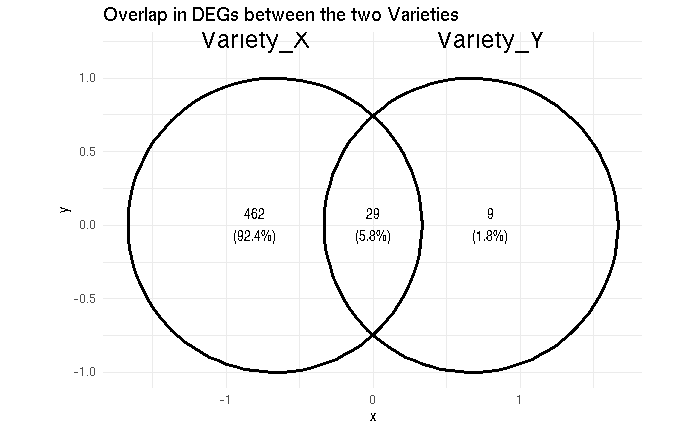

```r
varieties <- list(Variety_X = unique(var_x_degs$gene_name),
                  Variety_Y = unique(var_y_degs$gene_name))

ggvenn(varieties, fill_color = c("lightblue", "lightgreen")) +
  labs(title = "Overlap in DEGs between the two Varieties") +
  theme_minimal()
```

#Q10) SEPARATE OUT THE UP- AND DOWN- REGULATED DEGs (BETWEEN STRESS AND CONTROL CONDITION).

By looking at the gene expression data in the `var_x_degs` and `var_y_degs` data frames, you can see that some genes have a positive log 2 fold change and others have a negative log 2 fold change.

Add code to the chunk below that does the following: * Create a data frame called `var_x_degs.up` containing only genes that are upregulated in Stress Treatment compared to control in Variety X. * Create a data frame called `var_x_degs.down` containing only genes that are downregulated in Stress Treatment compared to control in Variety X. * Create a data frame called `var_y_degs.up` containing only genes that are upregulated in Stress Treatment compared to control in Variety Y. * Create a data frame called `var_y_degs.down` containing only genes that are downregulated in Stress Treatment compared to control in Variety Y. # 4 marks / 30 (total 15 so far).

```r
. = ottr::check("tests/q10.R")
```

#Q11) INVESTIGATE THE FOLD CHANGE IN GENE EXPRESSION FOR THE DEGs, BETWEEN STRESS AND CONTROL CONDITION.

Add code to the chunk below that does the following: * Create a box plot to show the distribution of log2 fold change for all DEGs by variety. Hint: the base R boxplot() command and the abs() function could be helpful here. * Create a box plot to show the distribution of log2 fold change for upregulated DEGs by variety. Hint: the base R boxplot() command could be helpful here. * Create a box plot to show the distribution of log2 fold change for downregulated DEGs by variety. Hint: the base R boxplot() command could be helpful here.

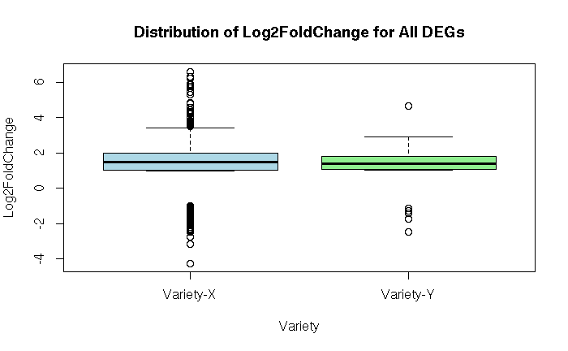

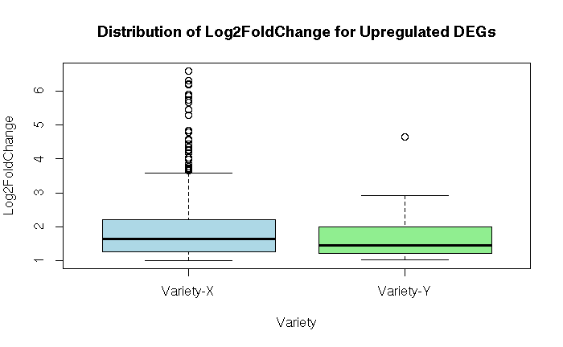

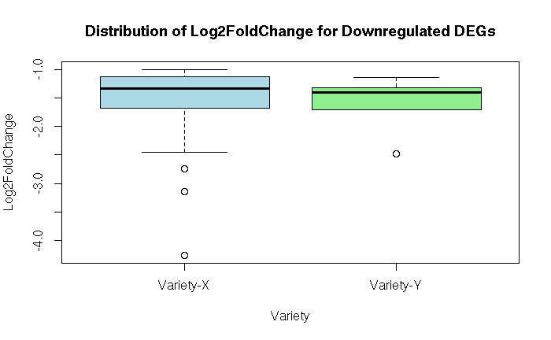

```r
## All DEGs
all_degs <- rbind(
  data.frame(variety = "Variety-X", log2FoldChange = var_x_degs$log2FoldChange),
  data.frame(variety = "Variety-Y", log2FoldChange = var_y_degs$log2FoldChange))

boxplot(log2FoldChange ~ variety, data = all_degs,
        main = "Distribution of Log2FoldChange for All DEGs",
        xlab = "Variety",
        ylab = "Log2FoldChange",
        col = c("lightblue", "lightgreen"))

## All upregulated DEGs
all_upregulated_degs <- rbind(
  data.frame(variety = "Variety-X", log2FoldChange = var_x_degs.up$log2FoldChange),
  data.frame(variety = "Variety-Y", log2FoldChange = var_y_degs.up$log2FoldChange))

boxplot(log2FoldChange ~ variety, data = all_upregulated_degs,
        main = "Distribution of Log2FoldChange for Upregulated DEGs",
        xlab = "Variety",
        ylab = "Log2FoldChange",
        col = c("lightblue", "lightgreen"))


## All downregulated DEGs
all_downregulated_degs <- rbind(
  data.frame(variety = "Variety-X", log2FoldChange = var_x_degs.down$log2FoldChange),
  data.frame(variety = "Variety-Y", log2FoldChange = var_y_degs.down$log2FoldChange))

boxplot(log2FoldChange ~ variety, data = all_downregulated_degs,
        main = "Distribution of Log2FoldChange for Downregulated DEGs",
        xlab = "Variety",
        ylab = "Log2FoldChange",
        col = c("lightblue", "lightgreen"))
```

#Q12) INVESTIGATE THE FUNCTIONS OF THE TOP MOST DIFFERENTIALLY EXPRESSED (DOWNREGULATED) GENES

Add code to the chunk below that does the following: * Find out the function of the most highly downregulated gene in Variety X and assign the result to variable called `top_gene.x`. * Find out the function of the most highly downregulated gene in Variety Y and assign the result to variable called `top_gene.y`. # 5 marks / 30 (total 20 so far).

```r
. = ottr::check("tests/q12.R")
```

#Q13) INVESTIGATE THE BEHAVIOUR OF THE BIOLOGICAL REPLICATES FOR THE DEGs in Variety X IN THE TREATMENT TIME POINT.

Add code to the chunk below that does the following: * Create a set of scatterplots to visually inspect how well the different replicates agree/correlate for the DEGs in Variety X in the treatment time point.

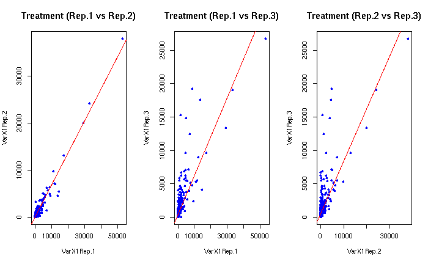

#Q14) INVESTIGATE THE BEHAVIOUR OF THE BIOLOGICAL REPLICATES FOR THE DEGs in Variety X IN THE CONTROL TIME POINT.

Add code to the chunk below that does the following: * Create a set of scatterplots to visually inspect how well the different replicates agree/correlate for the DEGs in Variety X in the control time point.

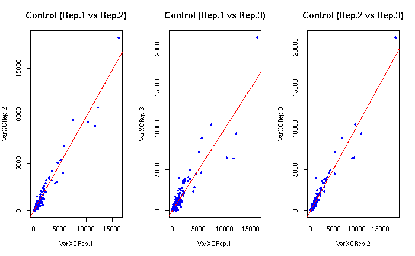

#Q15) COMPARE THE MEAN EXPRESSION IN TREATMENT VERSUS CONTROL REPLICATES FOR EACH DEG.

Add code to the chunk below that does the following: * Modify your data frame `var_x_degs` to include two new (additional) columns as follows: * The first new column should be named `control_mean` and contain the mean expression value for the three control replicates. * The second new column should be named `stress_mean` and contain the mean expression value for the three stress treatment replicates. # 6 marks / 30 (total 26 so far).

```r
. = ottr::check("tests/q15.R")
```

#Q16) PRIORITISE GENES OF INTEREST FOR FURTHER INVESTIGATION.

Add code to the chunk below that does the following: * Create a data frame called `var_x_degs.down.big` containing only genes in Variety x that are downregulated in Stress Treatment compared to control, have at least a 2 fold absolute change in expression and have a p value less than 1e-04. *Hint: remember you are dealing with log 2 fold change. # 4 marks / 30 (total 30 so far).

```r
# Create var_x_degs.down.big using base R
var_x_degs.down.big <- var_x_degs[var_x_degs$log2FoldChange < 0 &
                       abs(var_x_degs$log2FoldChange) >= log2(2) &
                       var_x_degs$padj < 1e-04]
```

```
Error in `[.data.frame`(var_x_degs, var_x_degs$log2FoldChange < 0 & abs(var_x_degs$log2FoldChange) >=  :
  undefined columns selected
```

```r
. = ottr::check("tests/q16.R")
```

END OF ASSESSMENT.